# Homework 3 - Naiara Alonso Montes

## Exercise 1 - Master Theorem

#### Exercise description

Solve recurrences by Master Theorem. Describe complexity class $\Theta()$.

- $T(n) = 4T(\frac{n}{2}) + n \log{}(n)$
- $T(n) = 6T(\frac{n}{2}) + n$
- $T(n) = 6T(\frac{n}{3}) + n \log{}(n)$
- $T(n) = 6T(\frac{n}{3}) + n^{2}$
- $T(n) = 9T(\frac{n}{3}) + n^{2}$
- $T(n) = 2T(\frac{2}{3} n) + n$

#### Solution

The Master Theorem stands for: $$T(n) = aT(\frac{n}{b}) + f(n)$$ With the following cases:

1. If $f(n) = O(n^{\log_{b}a-\epsilon})$ for some constant $\epsilon$ > 0, then $T(n) = \Theta(n^{\log_{b}a})$
2. If $f(n) = \Theta(n^{\log_{b}a.})$, then $T(n) = \Theta(n^{\log_{b}a}\log n)$.
3. If $f(n) = \Omega(n^{\log_{b}a +\epsilon})$ for some constant $\epsilon$ > 0, then $T(n) = \Theta(f(n))$.

With a representing the number of subproblems, b the factor in which the problem is divided and $n^{d}$ the cost of combining the subproblems (known as the non-recursive term).

Fourth recurrency: $$a = 6$$ $$b = 3$$ $$\log_{3}(6) ≈ 1.631$$ $$d = 2$$ $$ \text{Is } n^{2} > n^{1.631}\text{ ? Yes}$$ $$\Theta(n^{d}) = Θ(n^{2})$$

Fifth recurrency: $$a = 9$$ $$b = 3$$ $$\log_{3}(9) ≈ 2$$ $$d = 2$$ $$ \text{Is } n^{2} > n^{2}\text{ ? No, they are equal}$$ $$\Theta(n^{d}\log{}(n)) = Θ(n^{2}\log{}(n))$$

Sixth recurrency: $$a = 2$$ $$b = \frac{3}{2}$$ $$\log_{\frac{3}{2}}(2) ≈ 1.709$$ $$d = 1$$ $$ \text{Is } n^{1} > n^{1.709}\text{ ? No}$$ $$\Theta(n^{\log_{\frac{3}{2}}(2)}) = Θ(n^{1.709})$$

## Exercise 2 - Solving recurrences with similar approach

#### Exercise description

The following code generates random example recurrences, calculates them numerically by recursive simulation, and plots results. Example code generates random **a, b, f(n)** choices. https://colab.research.google.com/drive/10o2uJjddfvF8FW2f7_AvveQRLVhzP3hA

a,b - random values; f(n) $\in$ {n, n log(n), n<sup>2</sup>, n<sup>2.5</sup>, n<sup>3</sup>, n<sup>4</sup>}

If n < 10: T(n) = n

else: T(n) = a * T(n/b) + f(n)

First, familiarize yourself with the code.

1. Assess the benefit of **memoization** used in the code. Find examples where the effect of memoization is significant (like, at least 10x faster). Provide example T(n) and measurements of time with specific parameters n, with and without memoization.
2. **Identify** and **fix a set of five interesting combinations of the a,b, f(n)** in order to answer the following questions by plotting the chosen combinations.

Hint: Find cases where the growth of different T(n) functions visually clearly crosses on the plots). Provide a few such examples, where the f(n) component is “overshadowed” by the recurrence. i.e. the T(n) with lower f(n) class examples growing faster than more complex f(n) class component in the T( n ) = a * T( n/b) + f(n) ( e.g. recurrence with f(n)=n<sup>2</sup> is growing faster than recurrence with f(n)=n<sup>3</sup>). 3. Explain why and when this happens. Characterize the respective T(n) Theta(n) class

#### Solution

**1. Memoization speedup**

Memoization is a technique thats saves the output of an already calculated values and returns it when it is needed to be accesed again. It is specially useful in recursive functions.

For the initial configuration where:

- a = 2
- b = 1 + random(1, 5) / 5
- n = [$2^{n}$ for n in range(5, 16)]

The speed up obtained is the following:

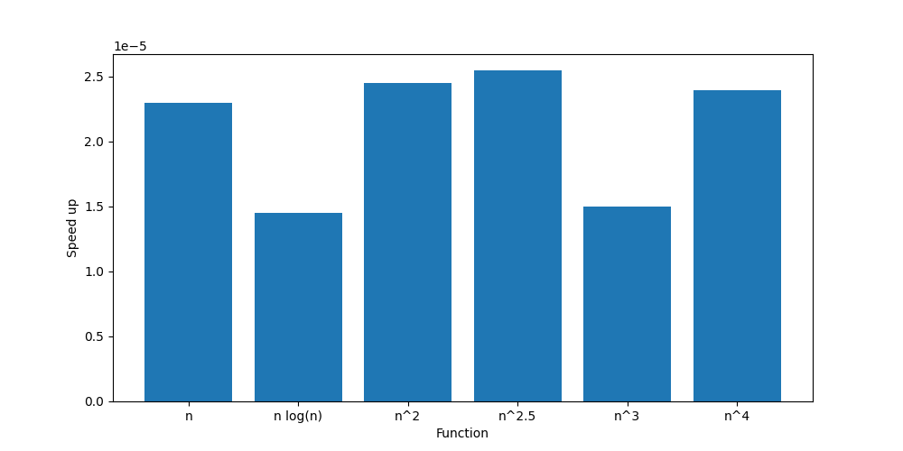

Now I'll try to show, with the same configuration of a and b, which is the point where memoization becomes benefitial, using different values of n.

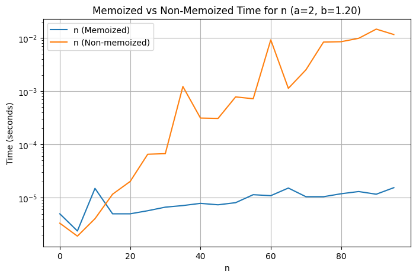

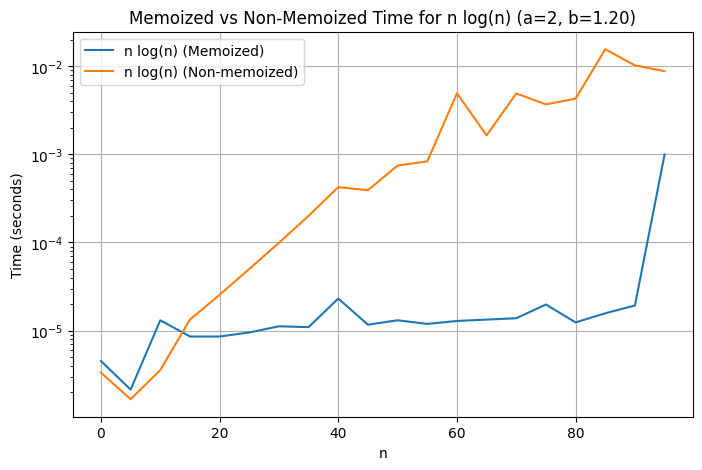

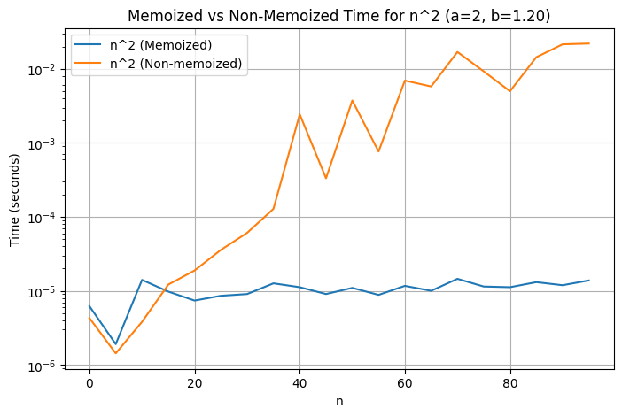

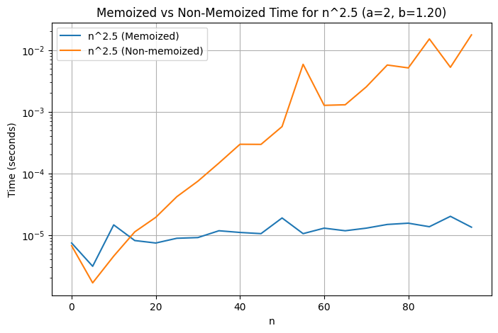

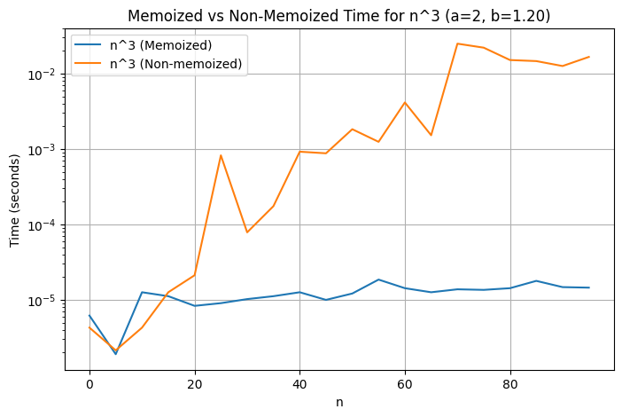

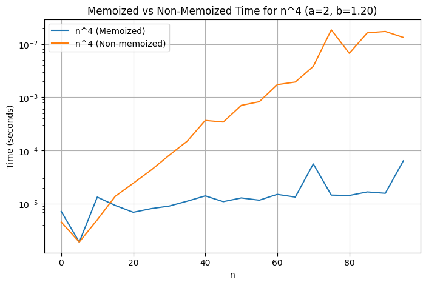

```python
import numpy as np
import matplotlib.pyplot as plt
import time
import math
import random

# Define function choices
f_choices = {
    "n": lambda n: n,
    "n log(n)": lambda n: n * math.log(n),
    "n^2": lambda n: n ** 2,
    "n^2.5": lambda n: n ** 2.5,
    "n^3": lambda n: n ** 3,
    "n^4": lambda n: n ** 4
}


# Define the memoized_T function
def memoized_T(a, b, f, n):
    memo = {}

    def T(n):
        if n in memo:
            return memo[n]
        if n < 10:  # Base case for n < 10
            result = n
        else:
            result = a * T(n // b) + f(n)
        memo[n] = result
        return result

    T(n)  # Run T(n) for the input n
    return memo


# Define the not_memoized_T2 function
def not_memoized_T2(a, b, f, n):
    memo = {}

    def T2(n):
        # if n in memo: return memo[n]           # Not using memoization if commented out
        if n < 10:  # Base case for n < 10
            result = n
        else:
            result = T2(n // b) + T2(n // b) + f(n)
        memo[n] = result
        return result

    T2(n)  # Run T2(n) for the input n
    return memo


# Measure time and collect results for each n value
def measure_time_for_each_n(func, a, b, f, n_values):
    times = []
    for n in n_values:
        start_time = time.time()
        func(a, b, f, n)
        elapsed_time = time.time() - start_time
        times.append(elapsed_time)
    return times


# Generate a list of random n values between 2^5 and 2^15
random_n_values = [i for i in range(0, 100, 5)]

# Define the parameters for the memoized_T function
a = 2
b = 1 + random.randint(1, 5) / 5

# Measure time for both memoized and non-memoized functions
for function in f_choices:
    name_f, f_func = function, f_choices[function]

    # Measure times for each n value
    memo_times = measure_time_for_each_n(memoized_T, a, b, f_func, random_n_values)
    not_memo_times = measure_time_for_each_n(not_memoized_T2, a, b, f_func, random_n_values)

    # Create a new plot for each function
    plt.figure(figsize=(8, 5))

    # Plot memoized times
    plt.plot(random_n_values, memo_times, label=f"{name_f} (Memoized)")

    # Plot non-memoized times
    plt.plot(random_n_values, not_memo_times, label=f"{name_f} (Non-memoized)")

    # Plot settings
    plt.xlabel("n")
    plt.ylabel("Time (seconds)")
    plt.title(f"Memoized vs Non-Memoized Time for {name_f} (a={a}, b={b:.2f})")
    plt.legend()
    plt.yscale('log')  # Use logarithmic scale for better visualization
    plt.grid(True)

    # Show each plot separately
    plt.show()
```

As seen in the plots for an n value of 17, using the memoized version is more efficient for all functions.

For finding a speed up 10x we have to find and n big enough. If we reuse part of the previous code and measure the speed up, we obtain the following graph.

```
For function n, the value of n where speed-up ≈ 10 is x ≈ 15.31
```

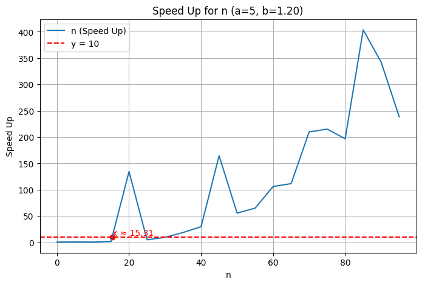

```
For function n log(n), the value of n where speed-up ≈ 10 is x ≈ 30.54
```

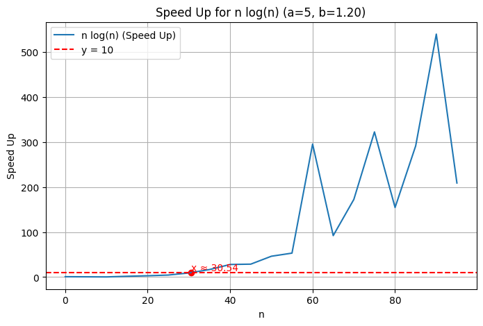

```
For function n^2, the value of n where speed-up ≈ 10 is x ≈ 33.16
```

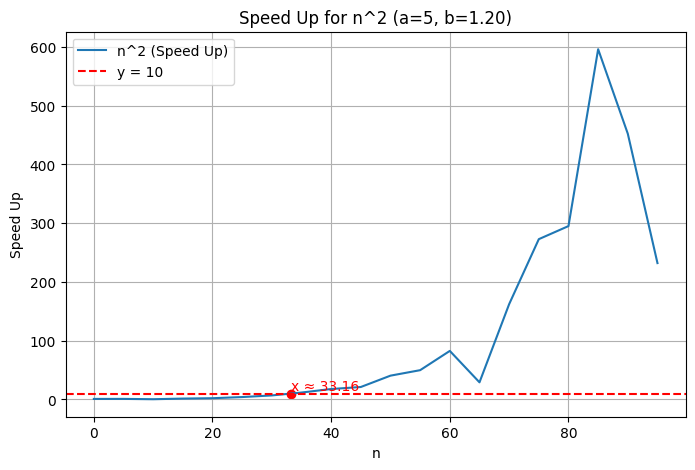

```
For function n^2.5, the value of n where speed-up ≈ 10 is x ≈ 32.91
```

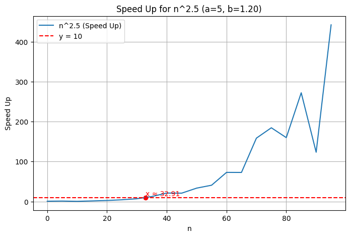

```
For function n^3, the value of n where speed-up ≈ 10 is x ≈ 33.19
```

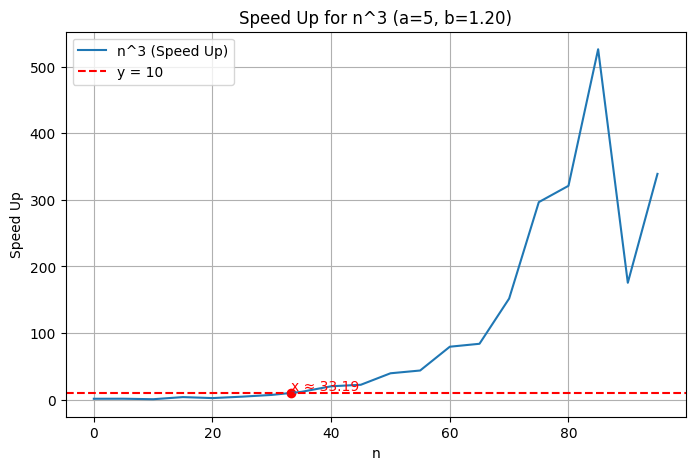

```
For function n^4, the value of n where speed-up ≈ 10 is x ≈ 31.88
```

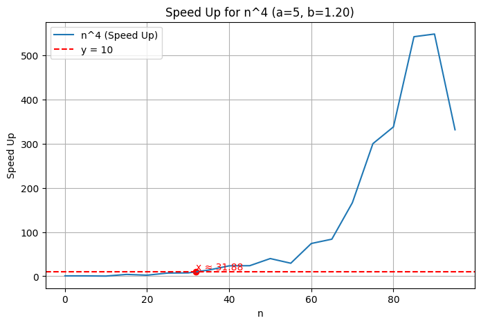

```python
# Interpolate x value for y = 10
def interpolate_x_at_y(x_values, y_values, y_target):
    for i in range(len(y_values) - 1):
        if y_values[i] <= y_target <= y_values[i + 1]:
            # Linear interpolation formula
            y1, y2 = y_values[i], y_values[i + 1]
            x1, x2 = x_values[i], x_values[i + 1]
            x_target = x1 + (y_target - y1) * (x2 - x1) / (y2 - y1)
            return x_target
    return None  # Return None if y_target is out of range

# Define n values
random_n_values = [i for i in range(0, 100, 5)]

# Measure time for both memoized and non-memoized functions
for function in f_choices:
    name_f, f_func = function, f_choices[function]

    # Measure times for each n value
    memo_times = measure_time_for_each_n(memoized_T, a, b, f_func, random_n_values)
    not_memo_times = measure_time_for_each_n(not_memoized_T2, a, b, f_func, random_n_values)

    # Calculate speed-up
    speed_up = [not_memo / memo for not_memo, memo in zip(not_memo_times, memo_times)]

    # Interpolate x value where y = 10
    x_at_y_10 = interpolate_x_at_y(random_n_values, speed_up, 10)

    # Print the x value where speed-up is 10
    if x_at_y_10:
        print(f"For function {name_f}, the value of n where speed-up ≈ 10 is x ≈ {x_at_y_10:.2f}")
    else:
        print(f"For function {name_f}, no n value gives speed-up = 10 within the range.")

    # Plot speed-up
    plt.figure(figsize=(8, 5))
    plt.plot(random_n_values, speed_up, label=f"{name_f} (Speed Up)")

    # Add a horizontal line at y = 10
    plt.axhline(y=10, color='r', linestyle='--', label=f'y = 10')

    # Annotate the plot with the x value at y = 10, if it exists
    if x_at_y_10:
        plt.scatter(x_at_y_10, 10, color='red')
        plt.text(x_at_y_10, 10, f"x ≈ {x_at_y_10:.2f}", color='red', verticalalignment='bottom')

    # Plot settings
    plt.xlabel("n")
    plt.ylabel("Speed Up")
    plt.title(f"Speed Up for {name_f} (a={a}, b={b:.2f})")
    plt.legend()
    plt.grid(True)
    plt.show()
```

According to the graphs we can say that when $n ≈ 32$, speed up is 10.

**2. a, b values combination** Instead of trying with random values until I find a solution, I have asked ChatGPT to predit some interesting combinations for a and b values.

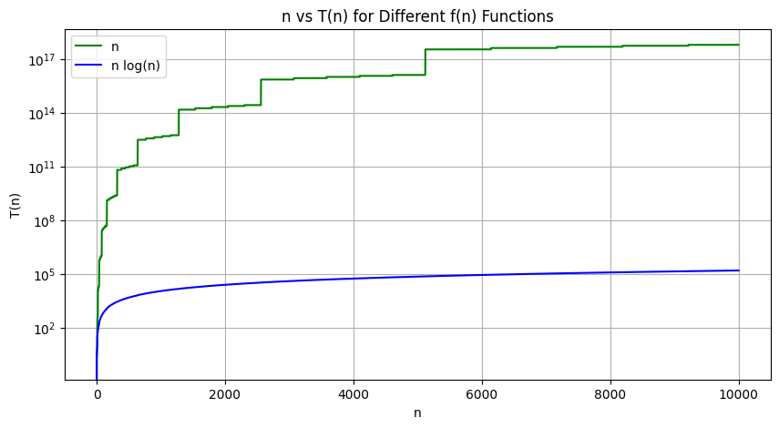

```python
# Generate a list of n values between 0 and 50 with a step of 2
n_values = [i for i in range(0, 10000)]

def measure_time_and_collect_results(func, a, b, f, n_values):
    combined_memo = {}
    start_time = time.time()
    for n in n_values:
        result = func(a, b, f, n)
        combined_memo.update(result)  # Merge new results into the combined memo
    elapsed_time = time.time() - start_time
    return combined_memo, elapsed_time

# Measure time for memoized_T
memo_T, time_T = measure_time_and_collect_results(memoized_T, 48, 2, f_choices["n"], n_values)
nemo_2_T, time_T2 = measure_time_and_collect_results(memoized_T, 2, 4, f_choices["n log(n)"], n_values)
#nemo_3_T, time_T3 = measure_time_and_collect_results(memoized_T, 32, 2, f_choices["n^2"], n_values)
#nemo_4_T, time_T4 = measure_time_and_collect_results(memoized_T, 4, 2, f_choices["n^2.5"], n_values)
#nemo_5_T, time_T5 = measure_time_and_collect_results(memoized_T, 4, 2, f_choices["n^3"], n_values)
#nemo_6_T, time_T6 = measure_time_and_collect_results(memoized_T, 4, 2, f_choices["n^4"], n_values)

# Plotting the results as lines for all functions on the same graph
plt.figure(figsize=(10, 5))
plt.plot(list(memo_T.keys()), list(memo_T.values()), color='green', label='n')
plt.plot(list(nemo_2_T.keys()), list(nemo_2_T.values()), color='blue', label='n log(n)')
#plt.plot(list(nemo_3_T.keys()), list(nemo_3_T.values()), color='red', label='n^2')
#plt.plot(list(nemo_4_T.keys()), list(nemo_4_T.values()), color='orange', label='n^2.5')
#plt.plot(list(nemo_5_T.keys()), list(nemo_5_T.values()), color='blue', label='n^3')
#plt.plot(list(nemo_6_T.keys()), list(nemo_6_T.values()), color='purple', label='n^4')

plt.title("n vs T(n) for Different f(n) Functions")
plt.xlabel("n")
plt.ylabel("T(n)")
plt.legend()
plt.yscale('log') # to better appreciate the growth
plt.grid(True)
plt.show()
```

If we exagerate the values of a and b, we can make lower rank $n$ to grow faster.

[output not shown]

**3. Explanaition**

$f(n)$ only means the number of operations to "rebuild" the problem, so if $a$, which is the size of the problem, is big enough, we can make $f(n)$ to have less influence on the final result.

### Exercise 3 - Complex interdependent recurrences

#### Exercise description

Perform a similar computational analysis for five random cases of a mutually dependent T1(n), T2(n), T3(n) based on the previous Task example (use the same or similar ranges for a,b,f as in the previous task). In each combination you would have three different ai, bi, fi. Select them randomly, but make them mutually different from each other (each ai is different, each bi and fi is different).

If $n < 10: T1(n) = T2(n) = T3(n) = n$

$T1(n) = a1 * T2(n/b1) + f1(n)$

$T2(n) = a2 * T3(n/b2) + f2(n)$

$T3(n) = a3 * T1(n/b3) + f3(n)$

1. Report the generated five combinations of T1, T2, T3 three-way recurrences by plotting their functions on a single plot (similar to Task 1).
2. How to determine the Theta() class in such three-way dependent recurrence? Select one such example, where you could possibly achieve a conclusive answer. Start from an example, where all $a_{i}$, $b_{i}$, $f_{i}$ are equal to each other. Then, change only one of the functions.
3. Find one or two examples where you think you have identified the correct overall complexity class when each Ti is clearly different from each other (different ai, bi, fi). Provide the plot with calculated values and most likely Theta(f(n)) class for selected functions.

#### Solution

**1. Generate random combinations and plot**

By modifying the previous code and adding the special recurrencies we get to the following

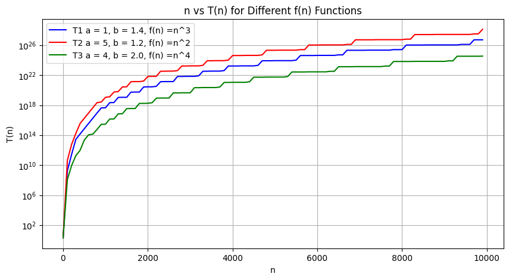

```python
a_choices = []
b_choices = []
f_choice_name = []
f_choice_func = []

while len(a_choices) < 3:
    a = random.randint(1, 5)
    if a not in a_choices:
        a_choices.append(a)

while len(b_choices) < 3:
    b = 1 + random.randint(1, 5) / 5
    if b not in b_choices:
        b_choices.append(b)

while len(f_choice_name) < 3:
    f_n, f_f = random.choice(list(f_choices.items()))
    if f_n not in f_choice_name:
        f_choice_name.append(f_n)
        f_choice_func.append(f_f)

memo_T1 = {}
memo_T2 = {}
memo_T3 = {}

def T1(n):
    f = f_choice_func[0]
    if n in memo_T1:
        return memo_T1[n]
    if n < 10:  # Base case for n < 10
        result = n
    else:
        result = a_choices[0] * T2(n // b_choices[0]) + f(n)
    memo_T1[n] = result
    return result

def T2(n):
    f = f_choice_func[1]
    if n in memo_T2:
        return memo_T2[n]
    if n < 10:  # Base case for n < 10
        result = n
    else:
        result = a_choices[1] * T2(n // b_choices[1]) + f(n)
    memo_T2[n] = result
    return result

def T3(n):
    f = f_choice_func[2]
    if n in memo_T3:
        return memo_T3[n]
    if n < 10:  # Base case for n < 10
        result = n
    else:
        result = a_choices[2] * T1(n // b_choices[2]) + f(n)
    memo_T3[n] = result
    return result

def measure_time_and_collect_results(func, n_values):
    combined_memo = {}
    start_time = time.time()
    for n in n_values:
        result = func(n)
        combined_memo[n] = result  # Merge new results into the combined memo
    elapsed_time = time.time() - start_time
    return combined_memo, elapsed_time

# Measure time for memoized_T
memo_T, time_T = measure_time_and_collect_results(T1, n_values)
nemo_2_T, time_T2 = measure_time_and_collect_results(T2, n_values)
nemo_3_T, time_T3 = measure_time_and_collect_results(T3, n_values)

# Plotting the results as lines for all functions on the same graph
plt.figure(figsize=(10, 5))

# Using 'plot' to draw lines and marker='o' to show dots at data points
plt.plot(list(memo_T.keys()), list(memo_T.values()), color='blue', label=f"T1 a = {a_choices[0]}, b = {b_choices[0]}, f(n) ={f_choice_name[0]}")
plt.plot(list(nemo_2_T.keys()), list(nemo_2_T.values()), color='red', label=f"T2 a = {a_choices[1]}, b = {b_choices[1]}, f(n) ={f_choice_name[1]}")
plt.plot(list(nemo_3_T.keys()), list(nemo_3_T.values()), color='green', label=f"T3 a = {a_choices[2]}, b = {b_choices[2]}, f(n) ={f_choice_name[2]}")

# Set logarithmic scale on the y-axis to better visualize large differences in growth
plt.yscale('log')

plt.title("n vs T(n) for Different f(n) Functions")
plt.xlabel("n")
plt.ylabel("T(n)")
plt.legend()
plt.grid(True)
plt.show()
```

**2. Determine Theta class**

One approach to solve this exercise is to substitue the recurrent term for each of the recurrencies and apply the Master's Theorem, asumming that $a_{1} = a_{2} = a_{3} = 3$ and $b_{1} = b_{2} = b_{3} = 2$. Let's start wit $T_1(n)$.

Substitue $_T3(n)$ into $T_2(n)$: $$T_2(n) = a_{2}\cdot(a_{3} * T_1(\frac{n}{b_{3}} + f_{3}(\frac{n}{b_{2}})) + f_{2}(n)$$ $$T_2(n) = a_{2} \cdot a_{3} \cdot T_1(\frac{n}{b_{2}\cdot b_{3}}) + a_{2} \cdot f_{3}(\frac{n}{b_{2}}) + f_{2}(n)$$ Then, substitue $T_2(n)$ into $T_1(n)$: $$T_1(n) = a_{1} \cdot (a_{2} \cdot a_{3} \cdot T_1(\frac{n}{b_{1}\cdot b_{2}\cdot b_{3}}) + a_{2} \cdot f_{3}(\frac{n}{b_{2}}) + f_{2}(\frac{n}{b_{1}})) + f_{1}(n)$$ $$T_1(n) = a_{1} ⋅ a_{2} ⋅ a_{3} ⋅ T_1(\frac{n}{b_{1}\cdot b_{2}\cdot b_{3}}) + a_{1} ⋅ a_{2} ⋅ f_{3}(\frac{n}{b_{2}}) + a_{1} ⋅ f_{2}(\frac{n}{b_{1}}) + f_{1}(n)$$

If we reduce the system:

$$T_1(n) = a_{1} ⋅ a_{2} ⋅ a_{3} ⋅ T_1(\frac{a}{b_{1} ⋅ b_{2} ⋅ b_{3}}) + \text{polynomial terms}$$

Now we substitue with the values of $a$ and $b$: $$T_1(n) = 27 ⋅ T_1(\frac{n}{8}) + f(n)$$ Where $f(n)$ is the sum of $f_{1}(n) = f_{2}(n) = f_{3}(n) = n^2$: $$T_1(n) = 27 ⋅ T_1(\frac{n}{8}) + n^{2}$$

If we apply the Master's Theorem for $a = 27, b = 8, d = 2$: $$\log_{b}(a) = \log_{8}(27) ≈ 1.585$$ Now we compare $d$ with $\log_{8}(27)$. Since $d > \log_{8}(27)$, the polynomial term $n^2$ dominates, and overall complexity is: $$T_1(n) = Θ(n^2)$$

By symmetry of recurrences, then: $$T(n) = Θ(n^2)$$

**3. Specific examples** To show how one affect the others, I will make $T_{1}$ non-depenant on the others, with a modified version of the code:

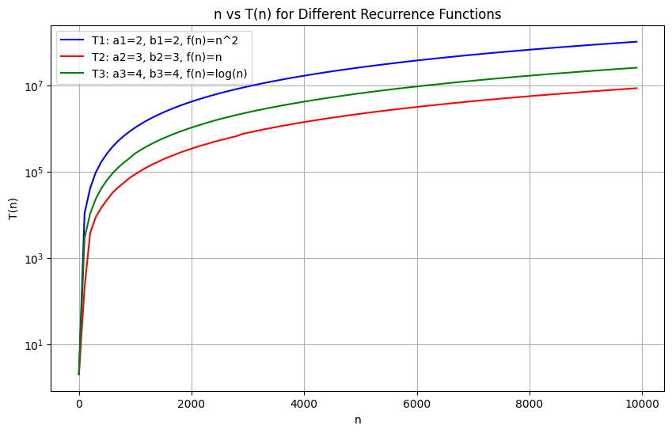

```python
def T1(n):
    if n < 10:
        return n
    return 24 * T1(n // 24) + 6 * math.log(n / 3) + 2 * n + n ** 2 # modified version

def T2(n):
    if n < 10:
        return n
    return 12 * T1(n // 12) + 3 * math.log(n / 3) + n

def T3(n):
    if n < 10:
        return n
    return 4 * T1(n // 4) + math.log(n)

# Generate the values for n
n_values = np.arange(2, 10000, 100)
T1_values = [T1(n) for n in n_values]
T2_values = [T2(n) for n in n_values]
T3_values = [T3(n) for n in n_values]

# Plot the results
plt.figure(figsize=(10, 6))
plt.plot(n_values, T1_values, label='T1: a1=2, b1=2, f(n)=n^2', color='blue')
plt.plot(n_values, T2_values, label='T2: a2=3, b2=3, f(n)=n', color='red')
plt.plot(n_values, T3_values, label='T3: a3=4, b3=4, f(n)=log(n)', color='green')

plt.yscale('log')
plt.xscale('linear')
plt.title("n vs T(n) for Different Recurrence Functions")
plt.xlabel("n")
plt.ylabel("T(n)")
plt.legend()
plt.grid(True)
plt.show()
```

We can change this values to see another example:

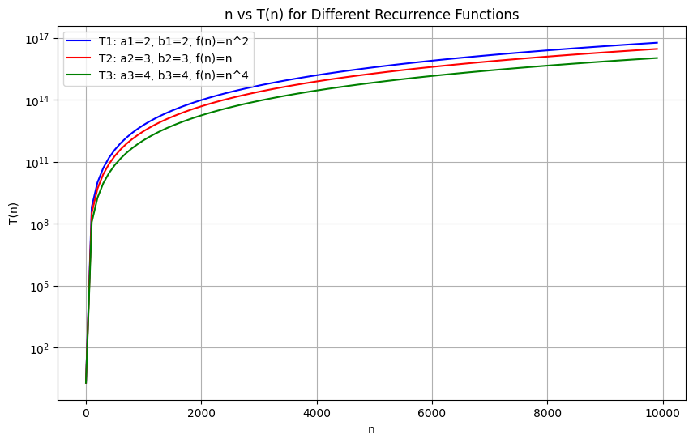

```python
def T1(n):
    if n < 10:
        return n
    return 24 * T1(n // 24) + 6 * n ** 4 + 2 * n + n ** 2 # modified version

def T2(n):
    if n < 10:
        return n
    return 12 * T1(n // 12) + 3 * n ** 4 + n

def T3(n):
    if n < 10:
        return n
    return 4 * T1(n // 4) + n ** 4

# Generate the values for n
n_values = np.arange(2, 10000, 100)
T1_values = [T1(n) for n in n_values]
T2_values = [T2(n) for n in n_values]
T3_values = [T3(n) for n in n_values]

# Plot the results
plt.figure(figsize=(10, 6))
plt.plot(n_values, T1_values, label='T1: a1=2, b1=2, f(n)=n^2', color='blue')
plt.plot(n_values, T2_values, label='T2: a2=3, b2=3, f(n)=n', color='red')
plt.plot(n_values, T3_values, label='T3: a3=4, b3=4, f(n)=n^4', color='green')

plt.yscale('log')
plt.xscale('linear')
plt.title("n vs T(n) for Different Recurrence Functions")
plt.xlabel("n")
plt.ylabel("T(n)")
plt.legend()
plt.grid(True)
plt.show()
```

### Exercise 4 - Bucket sort

#### Exercise description

Divide 10 000 points that are randomly uniformly distributed within the 3D sphere into “buckets” by the distance from origin. The Sphere is centered at the origin (0,0,0). Data generator: https://colab.research.google.com/drive/11_cMfMNJYfWrJM9kNIU9aRje-YwfMHVb#scrollTo=PpVVXrF_bpmW

- Experiment with pre-calculated boundaries for buckets. First, split data into ten buckets by providing the boundaries. Count the nr of points in each bucket. Next, split each bucket further into 5 using the same principle. Summarize the obtained buckets by a count of points in each 10x5 sub-buckets. Compare two approaches: a) equi-distant from origin, and b) expected “equi-size” buckets. See, that your results actually match your expectations.

Smth like: Bucket 1 [0 … 120) 1100 : 190 210 200 210 200 Bucket 2 [120 .. 190) 990 : 200 190 200 .. … (here numeric boundaries are only for top-10 split; for next split into 5 only the size of bucket is given)

- Implement a bucket-sorting algorithm for this type of data by splitting data recursively into roughly equal-size buckets and relying on a simpler method if the bucket has 10 or less items.
- What might be a good approach for determining the number of buckets to be used? From which bucket size should you rely on a simpler sorting method?
- Measure experimentally (feel free to increase the data size from the generator).
- Make a conclusion: how good is your Bucket sort compared to Quicksort for this particular type of data?

#### Solution

| Bucket | Sub-bucket 0 | Sub-bucket 1 | Sub-bucket 2 | Sub-bucket 3 | Sub-bucket 4 |
| --- | --- | --- | --- | --- | --- |
| **Bucket 0 (0.00 - 100.00): 2 points** | 0.00 - 20.00: 1 points | 20.00 - 40.00: 0 points | 40.00 - 60.00: 0 points | 60.00 - 80.00: 0 points | 80.00 - 100.00: 1 points |
| **Bucket 1 (100.00 - 199.99): 34 points** | 100.00 - 119.99: 1 points | 119.99 - 139.99: 4 points | 139.99 - 159.99: 5 points | 159.99 - 179.99: 14 points | 179.99 - 199.99: 10 points |
| **Bucket 2 (199.99 - 299.99): 108 points** | 199.99 - 219.99: 15 points | 219.99 - 239.99: 13 points | 239.99 - 259.99: 22 points | 259.99 - 279.99: 24 points | 279.99 - 299.99: 34 points |
| **Bucket 3 (299.99 - 399.98): 193 points** | 299.99 - 319.99: 35 points | 319.99 - 339.99: 35 points | 339.99 - 359.98: 40 points | 359.98 - 379.98: 41 points | 379.98 - 399.98: 42 points |
| **Bucket 4 (399.98 - 499.98): 306 points** | 399.98 - 419.98: 61 points | 419.98 - 439.98: 50 points | 439.98 - 459.98: 51 points | 459.98 - 479.98: 68 points | 479.98 - 499.98: 76 points |
| **Bucket 5 (499.98 - 599.97): 433 points** | 499.98 - 519.98: 76 points | 519.98 - 539.98: 75 points | 539.98 - 559.98: 82 points | 559.98 - 579.98: 92 points | 579.98 - 599.97: 108 points |
| **Bucket 6 (599.97 - 699.97): 644 points** | 599.97 - 619.97: 108 points | 619.97 - 639.97: 109 points | 639.97 - 659.97: 142 points | 659.97 - 679.97: 161 points | 679.97 - 699.97: 124 points |
| **Bucket 7 (699.97 - 799.97): 881 points** | 699.97 - 719.97: 187 points | 719.97 - 739.97: 180 points | 739.97 - 759.97: 151 points | 759.97 - 779.97: 176 points | 779.97 - 799.97: 187 points |
| **Bucket 8 (799.97 - 899.96): 1126 points** | 799.97 - 819.97: 204 points | 819.97 - 839.96: 215 points | 839.96 - 859.96: 224 points | 859.96 - 879.96: 225 points | 879.96 - 899.96: 258 points |
| **Bucket 9 (899.96 - 999.96): 1345 points** | 899.96 - 919.96: 233 points | 919.96 - 939.96: 273 points | 939.96 - 959.96: 261 points | 959.96 - 979.96: 271 points | 979.96 - 999.96: 307 points |

**Equi-size bucket counts and ranges:**

| Bucket | Sub-bucket 0 | Sub-bucket 1 | Sub-bucket 2 | Sub-bucket 3 | Sub-bucket 4 |
| --- | --- | --- | --- | --- | --- |
| **Bucket 0 (74.33 - 461.27): 506 points** | 74.33 - 151.72: 11 points | 151.72 - 229.11: 45 points | 229.11 - 306.50: 103 points | 306.50 - 383.88: 147 points | 383.88 - 461.27: 200 points |
| **Bucket 1 (461.38 - 588.36): 506 points** | 461.38 - 486.77: 85 points | 486.77 - 512.17: 101 points | 512.17 - 537.57: 91 points | 537.57 - 562.96: 104 points | 562.96 - 588.36: 125 points |
| **Bucket 2 (588.37 - 670.56): 506 points** | 588.37 - 604.81: 87 points | 604.81 - 621.25: 88 points | 621.25 - 637.69: 98 points | 637.69 - 654.13: 102 points | 654.13 - 670.56: 131 points |
| **Bucket 3 (670.60 - 733.05): 506 points** | 670.60 - 683.09: 91 points | 683.09 - 695.58: 77 points | 695.58 - 708.07: 112 points | 708.07 - 720.56: 111 points | 720.56 - 733.05: 115 points |
| **Bucket 4 (733.26 - 792.81): 506 points** | 733.26 - 745.17: 95 points | 745.17 - 757.08: 100 points | 757.08 - 768.99: 94 points | 768.99 - 780.90: 108 points | 780.90 - 792.81: 109 points |
| **Bucket 5 (792.81 - 841.67): 506 points** | 792.81 - 802.58: 92 points | 802.58 - 812.35: 105 points | 812.35 - 822.12: 100 points | 822.12 - 831.89: 101 points | 831.89 - 841.67: 108 points |
| **Bucket 6 (841.95 - 885.79): 506 points** | 841.95 - 850.72: 101 points | 850.72 - 859.49: 100 points | 859.49 - 868.26: 92 points | 868.26 - 877.02: 101 points | 877.02 - 885.79: 112 points |
| **Bucket 7 (885.81 - 926.86): 506 points** | 885.81 - 894.02: 90 points | 894.02 - 902.23: 113 points | 902.23 - 910.44: 95 points | 910.44 - 918.65: 105 points | 918.65 - 926.86: 103 points |
| **Bucket 8 (926.89 - 965.33): 506 points** | 926.89 - 934.58: 101 points | 934.58 - 942.27: 101 points | 942.27 - 949.95: 104 points | 949.95 - 957.64: 99 points | 957.64 - 965.33: 101 points |
| **Bucket 9 (965.34 - 999.96): 509 points** | 965.34 - 972.26: 82 points | 972.26 - 979.18: 108 points | 979.18 - 986.11: 110 points | 986.11 - 993.03: 103 points | 993.03 - 999.96: 106 points |

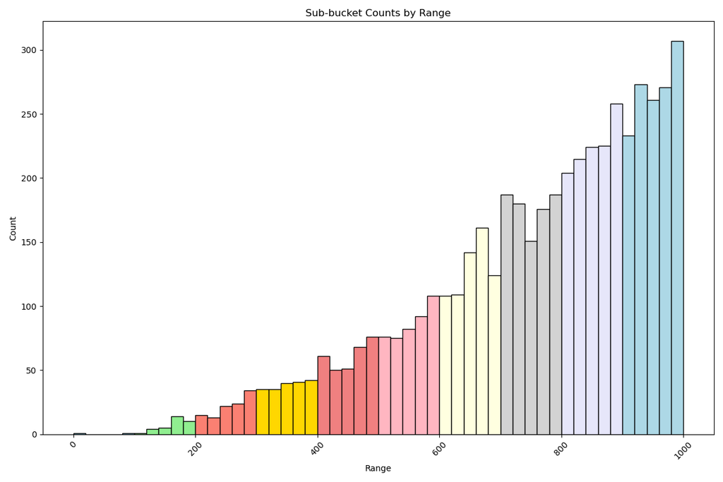

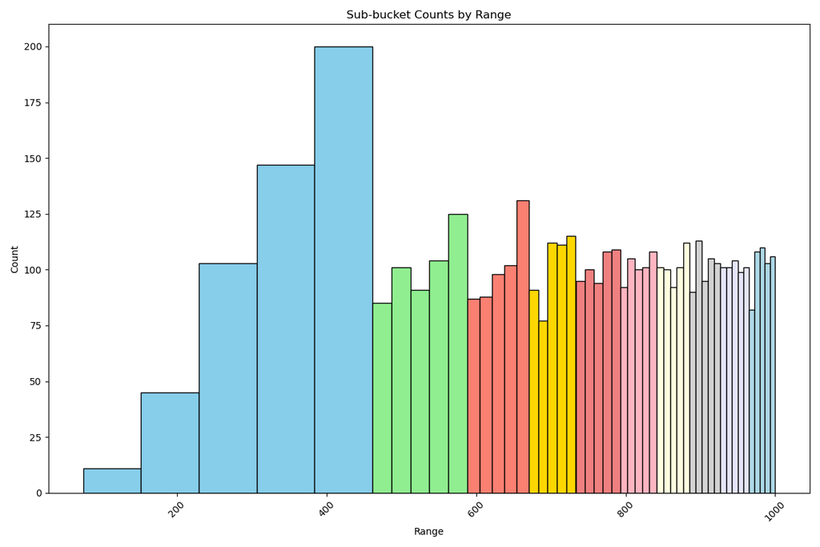

To implement a bucket sort, I will divide the each bucket until it reaches a size < 10, which can be easily sorted and then putting halfs together again. Here is the sorting algorithm:

```python
def sort_buckets(bucket):
    if len(bucket) <= 10:
        # return list of points sorted by distance
        sorted_points = [] * len(bucket)
        for point in bucket:
            distance = calculate_distance_to_center(point)
            sorted_points.append((point, distance))

        #return only the points sorted by distance from least to greatest
        sorted_points.sort(key=lambda x: x[1])
        sorted = [point for point, distance in sorted_points]
        return sorted
    else:
        # divide in half and sort each half
        half = len(bucket) // 2
        left = sort_buckets(bucket[:half])
        right = sort_buckets(bucket[half:])

        sorted_points = []
        for i in range(len(left)):
            sorted_points.append(left[i])
        for i in range(len(right)):
            sorted_points.append(right[i])
        return sorted_points

def sort(buckets):
    sorted_points = []
    for keys, bucket in buckets.items():
        for sub_bucket in bucket.values():
            sorted_points.append(sort_buckets(sub_bucket))
    return sorted_points


sorted_buckets = sort(points_in_buckets)
```

There is no right approach on how many buckets should we choose. We can decide some quality standards. As we saw, the better approach is to divide the points not based on distance from the center, it is better to do it based on number of elements per bucket. Knowing that we should stablish a relation to do not create a big number of buckets or a few. In this example:

- Number of big buckets equal to have at most one tenth of the total items.
- Number of sub-buckets equal to 5.

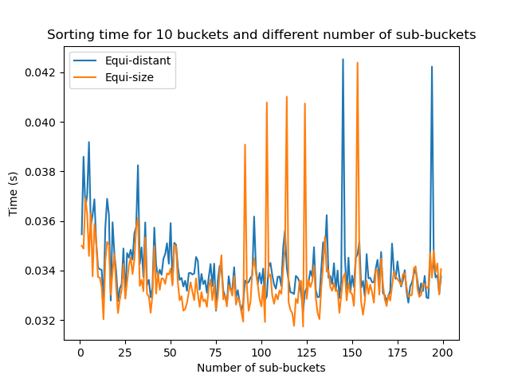

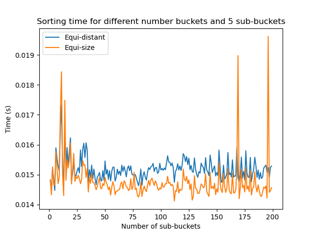

Based on the plots, we can say that equi-size performs better in time efficiency, but there are not major differences on what bucket and sub-bucket numbers to choose.

If we compare with quicksort:

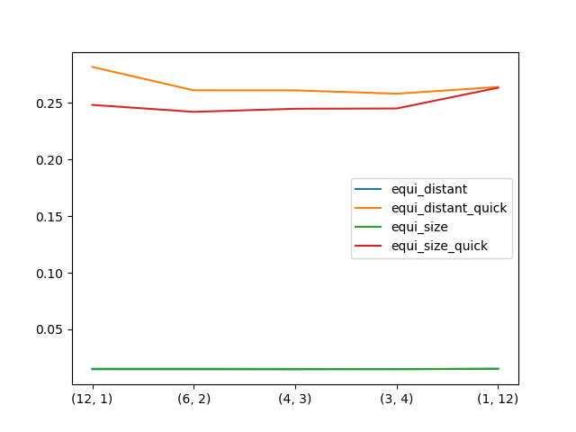

### Exercise 5 - Skip List

#### Exercise description

Implement the Skiplist class: Skiplist() Initializes the object of the skiplist. bool search(int target) Returns true if the integer target exists in the Skiplist or false otherwise. void add(int num) Inserts the value num into the SkipList. bool erase(int num) Removes the value num from the Skiplist and returns true. If num does not exist in the Skiplist, do nothing and return false. If there exist multiple num values, removing any one of them is fine.

1. Measure the speed of your implementation (in some meaningful way)
2. Calculate the memory consumption of your implementation of skip-list (how many pointers relative to values n?)
3. Vary how your skip-list class uses the probability to elevate an element with probability 1/x , e.g. test x in { 2, 4, 6, 8 }
4. Devise an experiment to compare the effect of choice of x - size and speed. Which x is the “best”?

#### Solution

To create the skiplist I'll use the suggested by ChatGPT [here](https://chatgpt.com/share/66efc555-7108-8003-b0e8-a33ffa8fdeaf), and to compare in a fair way I'll use the linked list class suggested [here](https://chatgpt.com/c/66efc846-0698-8003-9cef-efdb2b7d4d15).

The time measurement of comparison can be seen here:

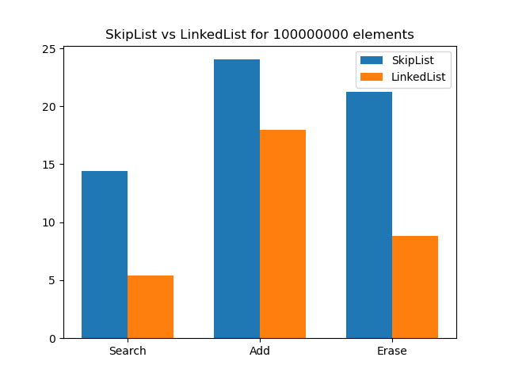

Where SkipList is not as efficient as LinkedList.

The number of pointers is related to the number of elements in the list and the maximun level. $$\text{Number of pointers} = \sum_{i = 0}^{\text{maxlevel}}(\frac{n}{2^{i}} ⋅ (i + 1))$$ If we apply the formula for 100 million elements we obtain that we need 399971008 pointers, in memory size it is approximately **3GB**.

If we change the max level with 20 elements the output is the following:

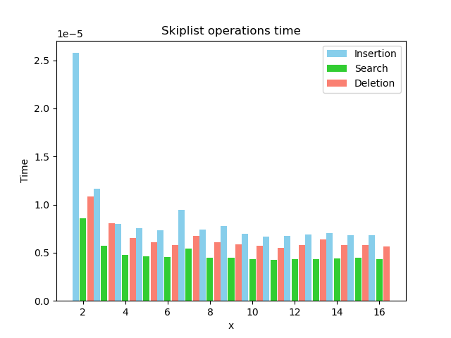

We appreciate that for small max level the time output tend to be higher, stabilizing when max level grows. This is because a lower level leads to a longer path of search.

```python
# to html
!jupyter nbconvert --to html HW3.ipynb
```